# Part I - (Dataset Exploration - Ford GoBike System)

## Introduction

> The Ford GoBike System is a public bike sharing system in the San Francisco Bay Area, California also called the Bay Wheels. Bay Wheels is the first regional and large-scale bicycle sharing system deployed in California and on the West Coast of the United States with nearly 500,000 rides since the launch in 2017 and had about 10,000 annual subscribers as of January 2018.

> This data set includes over 180,000 records/information about individual rides made in the bike-sharing system, their monthly individual trip data in February, 2019.

> I aim to get a general overview of the dataset and answwer questions relating to bike trips via exploratory & explanatory data analysis & visualizations.

```python
# import all packages and set plots to be embedded inline
import numpy as np
import pandas as pd
import matplotlib.pyplot as plt
import seaborn as sb
import os
import glob
import datetime as dt
import time, os, warnings

%matplotlib inline
```

### Loading and Assessing Data

> This would enable me get on with the overview of the data to see where cleaning is necessary and where further wrangling is necessary.

```python
bike_df = pd.read_csv('fordgobike_tripdata.csv')
bike_df.head()
```

|  | duration_sec | start_time | end_time | start_station_id | start_station_name | start_station_latitude | start_station_longitude | end_station_id | end_station_name | end_station_latitude | end_station_longitude | bike_id | user_type | member_birth_year | member_gender | bike_share_for_all_trip |
| --- | --- | --- | --- | --- | --- | --- | --- | --- | --- | --- | --- | --- | --- | --- | --- | --- |
| 0 | 52185 | 2019-02-28 17:32:10.1450 | 2019-03-01 08:01:55.9750 | 21.0 | Montgomery St BART Station (Market St at 2nd St) | 37.789625 | -122.400811 | 13.0 | Commercial St at Montgomery St | 37.794231 | -122.402923 | 4902 | Customer | 1984.0 | Male | No |
| 1 | 42521 | 2019-02-28 18:53:21.7890 | 2019-03-01 06:42:03.0560 | 23.0 | The Embarcadero at Steuart St | 37.791464 | -122.391034 | 81.0 | Berry St at 4th St | 37.775880 | -122.393170 | 2535 | Customer | NaN | NaN | No |
| 2 | 61854 | 2019-02-28 12:13:13.2180 | 2019-03-01 05:24:08.1460 | 86.0 | Market St at Dolores St | 37.769305 | -122.426826 | 3.0 | Powell St BART Station (Market St at 4th St) | 37.786375 | -122.404904 | 5905 | Customer | 1972.0 | Male | No |
| 3 | 36490 | 2019-02-28 17:54:26.0100 | 2019-03-01 04:02:36.8420 | 375.0 | Grove St at Masonic Ave | 37.774836 | -122.446546 | 70.0 | Central Ave at Fell St | 37.773311 | -122.444293 | 6638 | Subscriber | 1989.0 | Other | No |
| 4 | 1585 | 2019-02-28 23:54:18.5490 | 2019-03-01 00:20:44.0740 | 7.0 | Frank H Ogawa Plaza | 37.804562 | -122.271738 | 222.0 | 10th Ave at E 15th St | 37.792714 | -122.248780 | 4898 | Subscriber | 1974.0 | Male | Yes |

```python
# structure of the dataset
bike_df.info()
```

```
<class 'pandas.core.frame.DataFrame'>
RangeIndex: 183412 entries, 0 to 183411
Data columns (total 16 columns):
 #   Column                   Non-Null Count   Dtype
---  ------                   --------------   -----
 0   duration_sec             183412 non-null  int64
 1   start_time               183412 non-null  object
 2   end_time                 183412 non-null  object
 3   start_station_id         183215 non-null  float64
 4   start_station_name       183215 non-null  object
 5   start_station_latitude   183412 non-null  float64
 6   start_station_longitude  183412 non-null  float64
 7   end_station_id           183215 non-null  float64
 8   end_station_name         183215 non-null  object
 9   end_station_latitude     183412 non-null  float64
 10  end_station_longitude    183412 non-null  float64
 11  bike_id                  183412 non-null  int64
 12  user_type                183412 non-null  object
 13  member_birth_year        175147 non-null  float64
 14  member_gender            175147 non-null  object
 15  bike_share_for_all_trip  183412 non-null  object
dtypes: float64(7), int64(2), object(7)
memory usage: 22.4+ MB
```

- Some Null values are noticed in the birth_year, gender, stations (start and end) columns.

```python
# structure of the dataset
bike_df.isnull().sum()
```

```
duration_sec                  0
start_time                    0
end_time                      0
start_station_id            197
start_station_name          197
start_station_latitude        0
start_station_longitude       0
end_station_id              197
end_station_name            197
end_station_latitude          0
end_station_longitude         0
bike_id                       0
user_type                     0
member_birth_year          8265
member_gender              8265
bike_share_for_all_trip       0
dtype: int64
```

```python
bike_df.duplicated().sum()
```

```
0
```

```python
bike_df.member_gender.value_counts()
```

```
Male      130651
Female     40844
Other       3652
Name: member_gender, dtype: int64
```

```python
bike_df.user_type.value_counts()
```

```
Subscriber    163544
Customer       19868
Name: user_type, dtype: int64
```

```python
bike_df.bike_share_for_all_trip.value_counts()
```

```
No     166053
Yes     17359
Name: bike_share_for_all_trip, dtype: int64
```

```python
bike_df.describe()
```

|  | duration_sec | start_station_id | start_station_latitude | start_station_longitude | end_station_id | end_station_latitude | end_station_longitude | bike_id | member_birth_year |
| --- | --- | --- | --- | --- | --- | --- | --- | --- | --- |
| count | 183412.000000 | 183215.000000 | 183412.000000 | 183412.000000 | 183215.000000 | 183412.000000 | 183412.000000 | 183412.000000 | 175147.000000 |
| mean | 726.078435 | 138.590427 | 37.771223 | -122.352664 | 136.249123 | 37.771427 | -122.352250 | 4472.906375 | 1984.806437 |
| std | 1794.389780 | 111.778864 | 0.099581 | 0.117097 | 111.515131 | 0.099490 | 0.116673 | 1664.383394 | 10.116689 |
| min | 61.000000 | 3.000000 | 37.317298 | -122.453704 | 3.000000 | 37.317298 | -122.453704 | 11.000000 | 1878.000000 |
| 25% | 325.000000 | 47.000000 | 37.770083 | -122.412408 | 44.000000 | 37.770407 | -122.411726 | 3777.000000 | 1980.000000 |
| 50% | 514.000000 | 104.000000 | 37.780760 | -122.398285 | 100.000000 | 37.781010 | -122.398279 | 4958.000000 | 1987.000000 |
| 75% | 796.000000 | 239.000000 | 37.797280 | -122.286533 | 235.000000 | 37.797320 | -122.288045 | 5502.000000 | 1992.000000 |
| max | 85444.000000 | 398.000000 | 37.880222 | -121.874119 | 398.000000 | 37.880222 | -121.874119 | 6645.000000 | 2001.000000 |

```python
bike_df.shape
```

```
(183412, 16)
```

### What is the structure of your dataset?

The original data contains 183,412 individual trip records with 16 variables collected. The variables can be divided into 3 major categories:

> 1. trip duration: duration_sec, start_time, end_time
> 2. station info: start_station_id, start_station_name, start_station_latitude, start_station_longitude, end_station_id, end_station_name, end_station_latitude, end_station_longitude
> 3. member info (anonymized): bike_id, user_type, member_birth_year, member_gender, bike_share_for_all_trip

Derived features/variables to assist exploration and analysis:

> - trip info: duration_minute, start_date, start_hour_of_day, start_day_of_week, start_month member: member_age

### What is/are the main feature(s) of interest in your dataset?

> The main features I look to explore in the bike trips' are the duration and rental events occurrance patterns, along with how these relate to the riders' characteristics, i.e. their user type, gender, age, etc, to get a sense of how and what people are using the bike sharing service for.

### What features in the dataset do you think will help support your investigation into your feature(s) of interest?

> Each trip's start date/time and duration information will help me in understanding how long a trip usually takes and what day(s) of the week. The member information like user type, gender and age will help me find out who are the main target customer groups, use the different groups to summarize bike usage data to see if there is any special pattern associated with a specific group of riders.

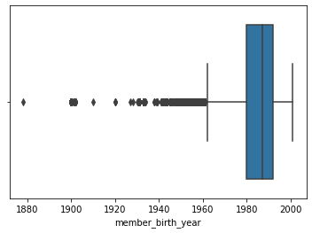

```python
# check outliers in the birth year column
sb.boxplot(bike_df['member_birth_year'])
```

- Outliers are noticed in the birth_year column.

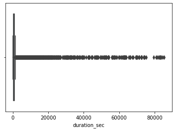

```python
# Check for outliers in duration column
sb.boxplot(bike_df['duration_sec']);
```

- It wouldn't be necessary to remove outliers in the duration column so as to avoid biased conclusions in my exploratory analysis.

```python
# based on the outlier view check for proportion of people born before 1920
born_before_1920 = len(bike_df[bike_df['member_birth_year']<1920])
before_1920_percent = born_before_1920/len(bike_df)
print (f'People who were born before 1920 represent {(before_1920_percent*100):.2f} %')
```

```
People who were born before 1920 represent 0.04 %
```

```python
# Check for duplications in data
def dup_checkremove(bike_df):
    df_nodup = bike_df.drop_duplicates()
    len_dup = len(bike_df)-len(df_nodup)
    if len_dup > 0 :
        print (f'There are {len_dup} duplicate values')
        print ('Removing duplicate values......')
        bike_df = bike_df.drop_duplicates()
    else :
        print ('There isn\'t any duplicate values .. you may proceed')
dup_checkremove(bike_df)
```

```
There isn't any duplicate values .. you may proceed
```

```python
# Check for values in columns with qualitative data
qualitative_cols = ['start_station_name', 'end_station_name', 'member_gender', 'bike_share_for_all_trip', 'user_type']
for col in qualitative_cols :
    print (bike_df[col].unique())
```

```
['Montgomery St BART Station (Market St at 2nd St)'
 'The Embarcadero at Steuart St' 'Market St at Dolores St'
 'Grove St at Masonic Ave' 'Frank H Ogawa Plaza'
 '4th St at Mission Bay Blvd S' 'Palm St at Willow St'
 'Washington St at Kearny St' 'Post St at Kearny St' 'Jones St at Post St'
 'Civic Center/UN Plaza BART Station (Market St at McAllister St)'
 'Valencia St at 21st St' 'Channing Way at Shattuck Ave'
 'Bancroft Way at College Ave' 'Howard St at Mary St'
 '22nd St at Dolores St' 'Laguna St at Hayes St' '5th St at Folsom'
 'Telegraph Ave at 23rd St' 'Page St at Scott St'
 'Lake Merritt BART Station' 'West St at 40th St'
 'The Embarcadero at Sansome St' 'Folsom St at 9th St'
 'University Ave at Oxford St' 'MLK Jr Way at University Ave'
 'The Embarcadero at Bryant St' '17th St at Valencia St'
 'Valencia St at 16th St' 'Valencia St at 22nd St' 'Franklin Square'
 'San Pablo Ave at MLK Jr Way' '19th St at Mission St'
 'Market St at 10th St' 'Folsom St at 13th St'
 'San Francisco Ferry Building (Harry Bridges Plaza)' '4th St at 16th St'
 'Beale St at Harrison St' 'Broadway at Battery St'
 'Cesar Chavez St at Dolores St' 'San Fernando St at 4th St'
 'Grove St at Divisadero' 'Sanchez St at 17th St'
 'Harmon St at Adeline St' 'Mission Playground' 'Davis St at Jackson St'
 'Haste St at Telegraph Ave' 'Howard St at 8th St' 'Folsom St at 3rd St'
 'Father Alfred E Boeddeker Park' 'Commercial St at Montgomery St'
 'Hubbell St at 16th St'
 'San Francisco Public Library (Grove St at Hyde St)'
 'Bancroft Way at Telegraph Ave' '19th Street BART Station'
 '18th St at Noe St' 'Hyde St at Post St' '24th St at Market St'
 'Vine St at Shattuck Ave'
 'San Francisco Caltrain (Townsend St at 4th St)'
 'Valencia St at Clinton Park' 'Union Square (Powell St at Post St)'
 'Broderick St at Oak St'
 'San Francisco Caltrain Station 2  (Townsend St at 4th St)'
 'North Berkeley BART Station' 'Downtown Berkeley BART'
 'Fell St at Stanyan St' 'San Salvador St at 9th St'
 'Marston Campbell Park' 'Oregon St at Adeline St' '11th St at Natoma St'
 'Harrison St at 20th St' 'Haste St at College Ave'
 '24th St at Bartlett St' 'Sanchez St at 15th St'
 'Telegraph Ave at 19th St' 'Powell St BART Station (Market St at 5th St)'
 'Jersey St at Castro St' 'Pierce St at Haight St'
```

[output cut: 250 more lines]

```
 'San Antonio Park' 'San Jose City Hall' 'Delmas Ave and San Fernando St'
 'Mendell St at Fairfax Ave' 'Santa Clara St at Almaden Blvd'
 'College Ave at Bryant Ave' 'Foothill Blvd at Fruitvale Ave'
 'Palm St at Willow St' 'Saint James Park' 'Williams Ave at 3rd St'
 'Market St at Park St' 'Almaden Blvd at Balbach St'
 'Almaden Blvd at San Fernando St' 'Foothill Blvd at 42nd Ave'
 'Fruitvale BART Station' 'MacArthur Blvd at Telegraph Ave'
 'Williams Ave at Apollo St' 'Mission St at 1st St'
 'San Pedro St at Hedding St' 'Oak St at 1st St'
 'Farnam St at Fruitvale Ave' '26th Ave at International Blvd'
 '16th St Depot' '21st Ave at International Blvd' 'Willow St at Vine St'
 '2nd St at Folsom St']
['Male' nan 'Other' 'Female']
['No' 'Yes']
['Customer' 'Subscriber']
```

- **Can I have had a different station names for the same station id? I would find out**

```python
# Checking if each station id only has one station name or more
start_st_ids = bike_df['start_station_id'].unique()
ids_multinames = []
for i in start_st_ids :
    station_names = bike_df[bike_df['start_station_id']==i]['start_station_name'].unique()
    if len(station_names) > 1:
        ids_multinames.append(i)
end_st_ids = bike_df['end_station_id'].unique()
for i in end_st_ids :
    station_names = bike_df[bike_df['end_station_id']==i]['end_station_name'].unique()
    if len(station_names) > 1:
        ids_multinames.append(i)
if len(ids_multinames) > 0 :
    print (f'Some stations have more than one name as in the following ids {ids}')
else :
    print ('All station ids have only one name .. you may proceed')
```

```
All station ids have only one name .. you may proceed
```

**From the previous overview, the following is found to be done in wrangling & cleaning step**

1. No Duplicate values were found
2. Missing values are found in gender, birth date, start & end stations column and all will be removed
3. Start, end time columns need to be modified into datetime data type.
4. New columns for day of week, day of month & hour will be created for better insight in the data
5. New column will be created showing Age from 'Birth year' column
6. Gender Column contains unneeded values 'Other', these records will also be removed.
7. Remove outliers in data (e.g. Age column), people born before 1920
8. Drop unnecessary columns in analysis

##### IMPORTANT THOUGHT - What are the main factors affecting number & duration of bike trips?

> 1. Location
> 2. Age
> 3. Gender
> 4. User type
> 5. Bike Share status
> 6. Time

### Cleaning Data

#### Issue 1: Remove all missing values

```python
bike_df = bike_df.dropna()
```

#### Check

```python
bike_df.info()
```

```
<class 'pandas.core.frame.DataFrame'>
Int64Index: 174952 entries, 0 to 183411
Data columns (total 16 columns):
 #   Column                   Non-Null Count   Dtype
---  ------                   --------------   -----
 0   duration_sec             174952 non-null  int64
 1   start_time               174952 non-null  object
 2   end_time                 174952 non-null  object
 3   start_station_id         174952 non-null  float64
 4   start_station_name       174952 non-null  object
 5   start_station_latitude   174952 non-null  float64
 6   start_station_longitude  174952 non-null  float64
 7   end_station_id           174952 non-null  float64
 8   end_station_name         174952 non-null  object
 9   end_station_latitude     174952 non-null  float64
 10  end_station_longitude    174952 non-null  float64
 11  bike_id                  174952 non-null  int64
 12  user_type                174952 non-null  object
 13  member_birth_year        174952 non-null  float64
 14  member_gender            174952 non-null  object
 15  bike_share_for_all_trip  174952 non-null  object
dtypes: float64(7), int64(2), object(7)
memory usage: 22.7+ MB
```

#### Issue 2: Modify datetime columns

```python
time_cols = ['start_time','end_time']
for col in time_cols:
    bike_df[col] = pd.to_datetime(bike_df[col])
```

#### Check

```python
bike_df.info()
```

```
<class 'pandas.core.frame.DataFrame'>
Int64Index: 174952 entries, 0 to 183411
Data columns (total 16 columns):
 #   Column                   Non-Null Count   Dtype
---  ------                   --------------   -----
 0   duration_sec             174952 non-null  int64
 1   start_time               174952 non-null  datetime64[ns]
 2   end_time                 174952 non-null  datetime64[ns]
 3   start_station_id         174952 non-null  float64
 4   start_station_name       174952 non-null  object
 5   start_station_latitude   174952 non-null  float64
 6   start_station_longitude  174952 non-null  float64
 7   end_station_id           174952 non-null  float64
 8   end_station_name         174952 non-null  object
 9   end_station_latitude     174952 non-null  float64
 10  end_station_longitude    174952 non-null  float64
 11  bike_id                  174952 non-null  int64
 12  user_type                174952 non-null  object
 13  member_birth_year        174952 non-null  float64
 14  member_gender            174952 non-null  object
 15  bike_share_for_all_trip  174952 non-null  object
dtypes: datetime64[ns](2), float64(7), int64(2), object(5)
memory usage: 22.7+ MB
```

#### Issue 3: Create new column (duration_minutes, day of week, day, hour)

```python
# create duration_minute column
bike_df['duration_minute'] = bike_df['duration_sec']/60


# day of week, day and hour
bike_df['start_day'] = bike_df['start_time'].dt.day
bike_df['start_day_of_week'] = bike_df['start_time'].dt.day_name()
bike_df['start_hour'] = bike_df['start_time'].dt.hour
bike_df['end_day'] = bike_df['end_time'].dt.day
bike_df['end_day_of_week'] = bike_df['end_time'].dt.day_name()
bike_df['end_hour'] = bike_df['end_time'].dt.hour
```

#### Check

```python
bike_df.info()
```

```
<class 'pandas.core.frame.DataFrame'>
Int64Index: 174952 entries, 0 to 183411
Data columns (total 23 columns):
 #   Column                   Non-Null Count   Dtype
---  ------                   --------------   -----
 0   duration_sec             174952 non-null  int64
 1   start_time               174952 non-null  datetime64[ns]
 2   end_time                 174952 non-null  datetime64[ns]
 3   start_station_id         174952 non-null  float64
 4   start_station_name       174952 non-null  object
 5   start_station_latitude   174952 non-null  float64
 6   start_station_longitude  174952 non-null  float64
 7   end_station_id           174952 non-null  float64
 8   end_station_name         174952 non-null  object
 9   end_station_latitude     174952 non-null  float64
 10  end_station_longitude    174952 non-null  float64
 11  bike_id                  174952 non-null  int64
 12  user_type                174952 non-null  object
 13  member_birth_year        174952 non-null  float64
 14  member_gender            174952 non-null  object
 15  bike_share_for_all_trip  174952 non-null  object
 16  duration_minute          174952 non-null  float64
 17  start_day                174952 non-null  int64
 18  start_day_of_week        174952 non-null  object
 19  start_hour               174952 non-null  int64
 20  end_day                  174952 non-null  int64
 21  end_day_of_week          174952 non-null  object
 22  end_hour                 174952 non-null  int64
dtypes: datetime64[ns](2), float64(8), int64(6), object(7)
memory usage: 32.0+ MB
```

#### Issue 4: Create new age column

```python
bike_df['age'] = 2019 - bike_df['member_birth_year']
bike_df.info()
```

```
<class 'pandas.core.frame.DataFrame'>
Int64Index: 174952 entries, 0 to 183411
Data columns (total 24 columns):
 #   Column                   Non-Null Count   Dtype
---  ------                   --------------   -----
 0   duration_sec             174952 non-null  int64
 1   start_time               174952 non-null  datetime64[ns]
 2   end_time                 174952 non-null  datetime64[ns]
 3   start_station_id         174952 non-null  float64
 4   start_station_name       174952 non-null  object
 5   start_station_latitude   174952 non-null  float64
 6   start_station_longitude  174952 non-null  float64
 7   end_station_id           174952 non-null  float64
 8   end_station_name         174952 non-null  object
 9   end_station_latitude     174952 non-null  float64
```

[output cut: 16 more lines]

**Setup some features to now check for outliers in new Age column.**

```python
pd.set_option('display.max_columns', None) # Show all datafram columns.
sb.set(style="whitegrid", font_scale=1.25, rc={'figure.figsize':(20,7)})
base_color = sb.color_palette()[0]
```

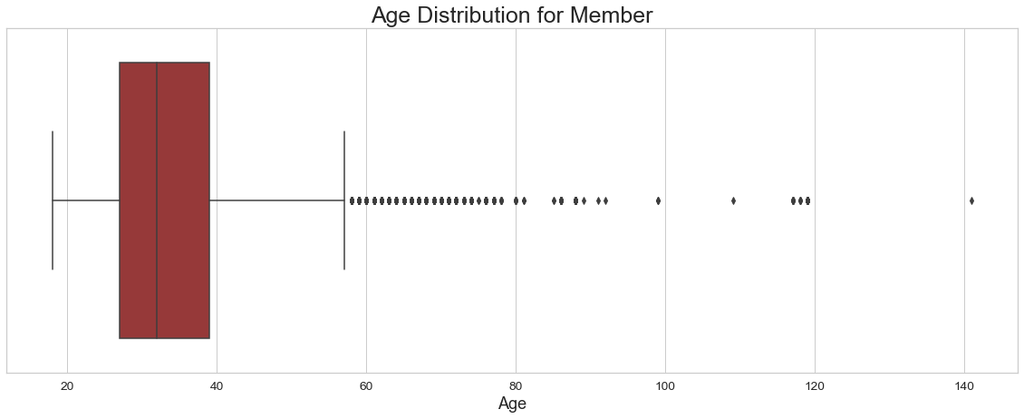

```python
ax = sb.boxplot(x=bike_df["age"], color='brown')
ax.set_xlabel('Age', fontsize=18)
ax.set_title("Age Distribution for Member", fontsize=25);
```

- This is showing the great age disparity and spread of the age of bike riders, seeing that there are many outliers from the age of 57 and above

#### Issue 5: Drop odd values in gender column

```python
ids = bike_df[bike_df['member_gender']=='Other'].index
bike_df = bike_df.drop(index=ids)
```

#### Check

```python
bike_df.info()
```

```
<class 'pandas.core.frame.DataFrame'>
Int64Index: 171305 entries, 0 to 183411
Data columns (total 24 columns):
 #   Column                   Non-Null Count   Dtype
---  ------                   --------------   -----
 0   duration_sec             171305 non-null  int64
 1   start_time               171305 non-null  datetime64[ns]
 2   end_time                 171305 non-null  datetime64[ns]
 3   start_station_id         171305 non-null  float64
 4   start_station_name       171305 non-null  object
 5   start_station_latitude   171305 non-null  float64
 6   start_station_longitude  171305 non-null  float64
 7   end_station_id           171305 non-null  float64
 8   end_station_name         171305 non-null  object
 9   end_station_latitude     171305 non-null  float64
```

[output cut: 16 more lines]

#### Issue 6: Remove outliers in Birth year column

```python
ids = bike_df[bike_df['member_birth_year']<1920].index
bike_df = bike_df.drop(index=ids)
```

#### Check

```python
bike_df.describe()
```

|  | duration_sec | start_station_id | start_station_latitude | start_station_longitude | end_station_id | end_station_latitude | end_station_longitude | bike_id | member_birth_year | duration_minute | start_day | start_hour | end_day | end_hour | age |
| --- | --- | --- | --- | --- | --- | --- | --- | --- | --- | --- | --- | --- | --- | --- | --- |
| count | 171234.000000 | 171234.000000 | 171234.000000 | 171234.000000 | 171234.000000 | 171234.000000 | 171234.000000 | 171234.000000 | 171234.000000 | 171234.000000 | 171234.000000 | 171234.000000 | 171234.000000 | 171234.000000 | 171234.000000 |
| mean | 697.775559 | 138.682388 | 37.770616 | -122.351656 | 136.303672 | 37.770817 | -122.351226 | 4481.259376 | 1984.874493 | 11.629593 | 15.309903 | 13.451587 | 15.309465 | 13.605592 | 34.125507 |
| std | 1577.550958 | 111.702181 | 0.101242 | 0.118536 | 111.418601 | 0.101147 | 0.118103 | 1659.530606 | 9.969689 | 26.292516 | 8.036099 | 4.733841 | 8.036246 | 4.747274 | 9.969689 |
| min | 61.000000 | 3.000000 | 37.317298 | -122.453704 | 3.000000 | 37.317298 | -122.453704 | 11.000000 | 1920.000000 | 1.016667 | 1.000000 | 0.000000 | 1.000000 | 0.000000 | 18.000000 |
| 25% | 322.250000 | 47.000000 | 37.770083 | -122.411901 | 44.000000 | 37.770407 | -122.411647 | 3796.000000 | 1980.000000 | 5.370833 | 8.000000 | 9.000000 | 8.000000 | 9.000000 | 27.000000 |
| 50% | 509.000000 | 104.000000 | 37.780760 | -122.398279 | 100.000000 | 37.781010 | -122.397437 | 4960.000000 | 1987.000000 | 8.483333 | 15.000000 | 14.000000 | 15.000000 | 14.000000 | 32.000000 |
| 75% | 787.000000 | 239.000000 | 37.797280 | -122.283127 | 237.000000 | 37.797320 | -122.287610 | 5505.000000 | 1992.000000 | 13.116667 | 22.000000 | 17.000000 | 22.000000 | 18.000000 | 39.000000 |
| max | 84548.000000 | 398.000000 | 37.880222 | -121.874119 | 398.000000 | 37.880222 | -121.874119 | 6645.000000 | 2001.000000 | 1409.133333 | 28.000000 | 23.000000 | 28.000000 | 23.000000 | 99.000000 |

#### Issue 7: Drop the unnecesary columns

```python
bike_df.columns
```

```
Index(['duration_sec', 'start_time', 'end_time', 'start_station_id',
       'start_station_name', 'start_station_latitude',
       'start_station_longitude', 'end_station_id', 'end_station_name',
       'end_station_latitude', 'end_station_longitude', 'bike_id', 'user_type',
       'member_birth_year', 'member_gender', 'bike_share_for_all_trip',
       'duration_minute', 'start_day', 'start_day_of_week', 'start_hour',
       'end_day', 'end_day_of_week', 'end_hour', 'age'],
      dtype='object')
```

```python
unnecessary_cols = ['start_time', 'end_time', 'start_station_id', 'start_station_name','end_station_name','start_station_latitude', 'start_station_longitude',
                    'end_station_id', 'end_station_latitude', 'end_station_longitude','member_birth_year']
bike_df = bike_df.drop(columns=unnecessary_cols,axis=1)
```

#### Check

```python
bike_df.info()
```

```
<class 'pandas.core.frame.DataFrame'>
Int64Index: 171234 entries, 0 to 183411
Data columns (total 13 columns):
 #   Column                   Non-Null Count   Dtype
---  ------                   --------------   -----
 0   duration_sec             171234 non-null  int64
 1   bike_id                  171234 non-null  int64
 2   user_type                171234 non-null  object
 3   member_gender            171234 non-null  object
 4   bike_share_for_all_trip  171234 non-null  object
 5   duration_minute          171234 non-null  float64
 6   start_day                171234 non-null  int64
 7   start_day_of_week        171234 non-null  object
 8   start_hour               171234 non-null  int64
 9   end_day                  171234 non-null  int64
 10  end_day_of_week          171234 non-null  object
 11  end_hour                 171234 non-null  int64
 12  age                      171234 non-null  float64
dtypes: float64(2), int64(6), object(5)
memory usage: 18.3+ MB
```

#### Issue 8: Set Weekday in order of Monday - Sunday

```python
weekday = ['Monday', 'Tuesday', 'Wednesday', 'Thursday', 'Friday', 'Saturday', 'Sunday']
weekdaycat = pd.api.types.CategoricalDtype(ordered=True, categories=weekday)
bike_df['start_day_of_week'] = bike_df['start_day_of_week'].astype(weekdaycat)
```

### Exploratory Data Analysis & Visualizations

## Univariate Exploration

- I would get overview of columns to know the effect of some features on number of bike trips

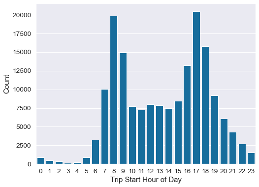

```python
# A plot to explore the trips distribution over hour-of-day

plt.rcParams['figure.figsize'] = 8, 6
base_color = sb.color_palette('colorblind')[0]
sb.set_style('darkgrid')

sb.countplot(data=bike_df, x='start_hour', color=base_color);
plt.xlabel('Trip Start Hour of Day');
plt.ylabel('Count');
```

- The plot shows the distribution of trips over the hours each day, seeing that most trips happen at 8 AM (definitely when most people go out to get to work or morning exercises/cycling) and at the evening hour of 17 Hour/PM, when many would be returning home from work.

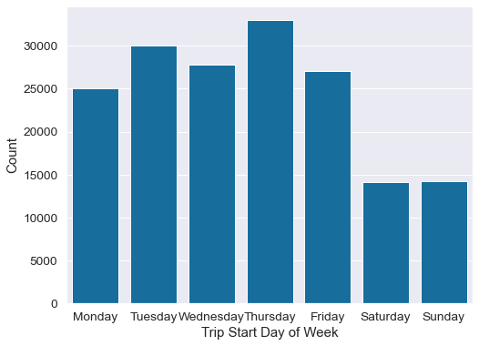

```python
# A plot to explore the trips distribution over day-of-week.

sb.countplot(data=bike_df, x='start_day_of_week', color=base_color);
plt.xlabel('Trip Start Day of Week');
plt.ylabel('Count');
```

- Looking in combined with the trip distribution over day of week plot, it is quite obvious that the majority of rides happened on work days (Mon-Fri) and primary usage is probably for commuting.
- The next plots are around members/users to see what makes up of the riders.

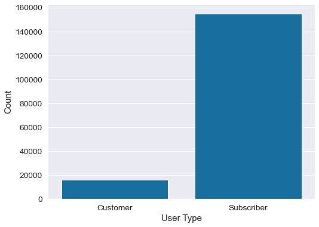

```python
sb.countplot(data=bike_df, x='user_type', color=base_color);
plt.xlabel('User Type');
plt.ylabel('Count');
```

- This plot shows the major distribution between the two groups that use the bike system, showing that over 140,000 users of the bikes are subscribers compared to the less than 20,000 customers.

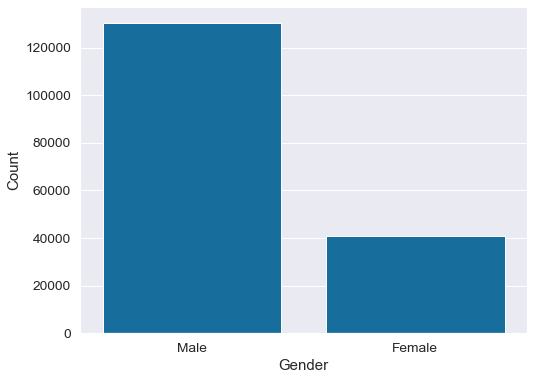

```python
sb.countplot(data=bike_df, x='member_gender', color=base_color);
plt.xlabel('Gender');
plt.ylabel('Count');
```

- Most riders were who use the bike system are male (with the greater percentage being subscribers) compared to the about 40,000 female gender using the back.

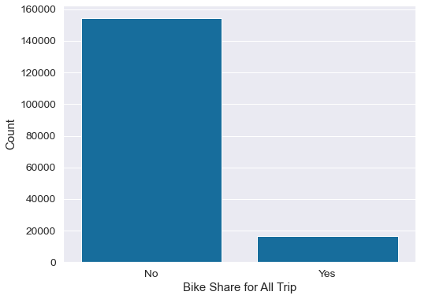

```python
sb.countplot(data=bike_df, x='bike_share_for_all_trip', color=base_color);
plt.xlabel('Bike Share for All Trip');
plt.ylabel('Count');
```

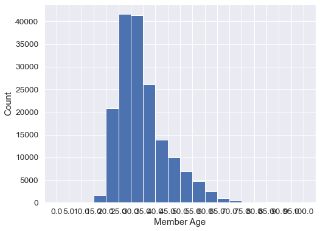

```python
bins = np.arange(0, bike_df['age'].max()+5, 5)
plt.hist(data=bike_df, x='age', bins=bins);
plt.xticks(bins, bins);
plt.xlabel('Member Age');
plt.ylabel('Count');
```

- Most members were around 25 to 40 years old, corresponding to the trip distribution plots that most trips were on Mon-Fri and maxed during rush hours of a day. As the age gets older, bike usage dropped significantly.

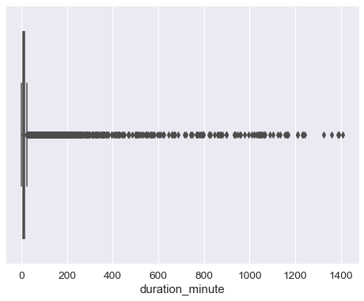

```python
# Check for outliers in duration_minute column
sb.boxplot(bike_df['duration_minute']);
```

- Most rides were quick and short, lasted between 5 to 10 minutes, though there were some very long outliers like 24hrs.
- No transformation was needed luckily due to the straightforwardness of the data.

```python
# Get proportion of different categories to total users

male_prop = len(bike_df[bike_df['member_gender']=='Male'])/len(bike_df)
sub_prop = len(bike_df[bike_df['user_type']=='Subscriber'])/len(bike_df)
no_prop = len(bike_df[bike_df['bike_share_for_all_trip']=='No'])/len(bike_df)
weekend_prop = (len(bike_df[bike_df['start_day_of_week']=='Thursday'])+len(bike_df[bike_df['start_day_of_week']=='Friday']))/len(bike_df)

print (f'Male trips represent percentage of {(male_prop*100):.2f} % From the total trips')
print (f'Subscribers trips represent percentage of {(sub_prop*100):.2f} % From the total trips')
print(f'users who doesn\'t share bike represent percentage of {(no_prop*100):.2f} % From the total trips')
print (f'weekend days (thursday, friday) represent percentage of {(weekend_prop*100):.2f} % From the total trips')
```

```
Male trips represent percentage of 76.18 % From the total trips
Subscribers trips represent percentage of 90.59 % From the total trips
users who doesn't share bike represent percentage of 90.26 % From the total trips
weekend days (thursday, friday) represent percentage of 35.06 % From the total trips
```

## Report and Explanatory Data Visualization

1. **What are the most common times for having bike trips? and is there a difference in relation to the biker's gender?**

> The Following Graphs are showing the most common days & hours where we have bike trips for both genders

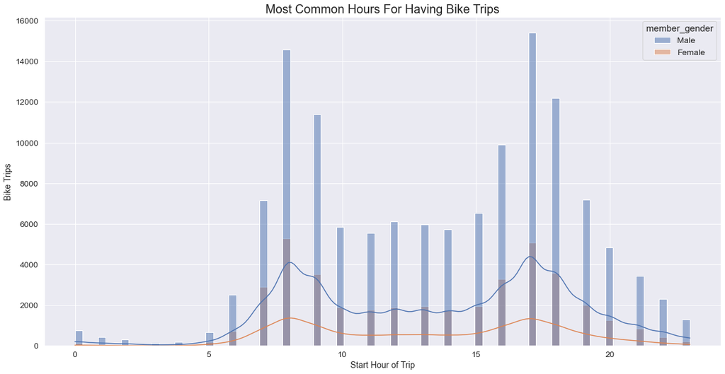

```python
# Plot for most common hours for having bike trips in relation to gender

fig, ax = plt.subplots(figsize=(20,10))
ax = sb.histplot(data=bike_df, x=bike_df['start_hour'], hue='member_gender', kde=True)
plt.title('Most Common Hours For Having Bike Trips', fontsize=20)
plt.ylabel('Bike Trips', fontsize=14)
plt.xlabel('Start Hour of Trip', fontsize=14)
```

- The trip distribution over day hours peaks around two timeframes, 8am-9am and 17pm-18pm, during typical rush hours.

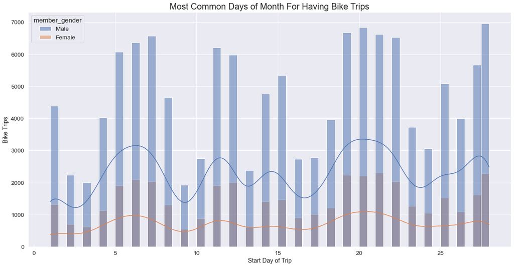

```python
# Plot the most common days to have bike trips in relation to gender

fig, ax = plt.subplots(figsize=(20,10))
ax = sb.histplot(data=bike_df, x=bike_df['start_day'], hue='member_gender', kde=True)
plt.title('Most Common Days of Month For Having Bike Trips', fontsize=20)
plt.ylabel('Bike Trips', fontsize=14)
plt.xlabel('Start Day of Trip', fontsize=14);
```

**2. Check to see Why certain Days have higher trip rates ? - days of the week**

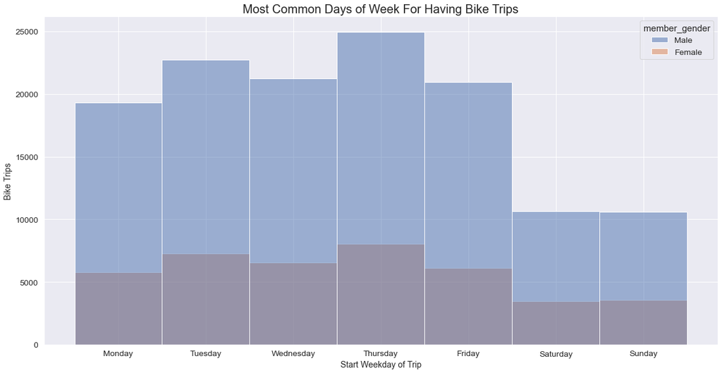

```python
fig, ax = plt.subplots(figsize=(20,10))
ax = sb.histplot(data=bike_df, x=bike_df['start_day_of_week'], hue='member_gender')
plt.title('Most Common Days of Week For Having Bike Trips', fontsize=20)
plt.ylabel('Bike Trips', fontsize=14)
plt.xlabel('Start Weekday of Trip', fontsize=14);
```

- The very high patronage of the subcribers and customers of the bike system on Thursdays, perhaps for the time where it's close to the weekend explains why there are higher trip rates on that day.
1. **What is the main age range & gender of target for bike trips ?**

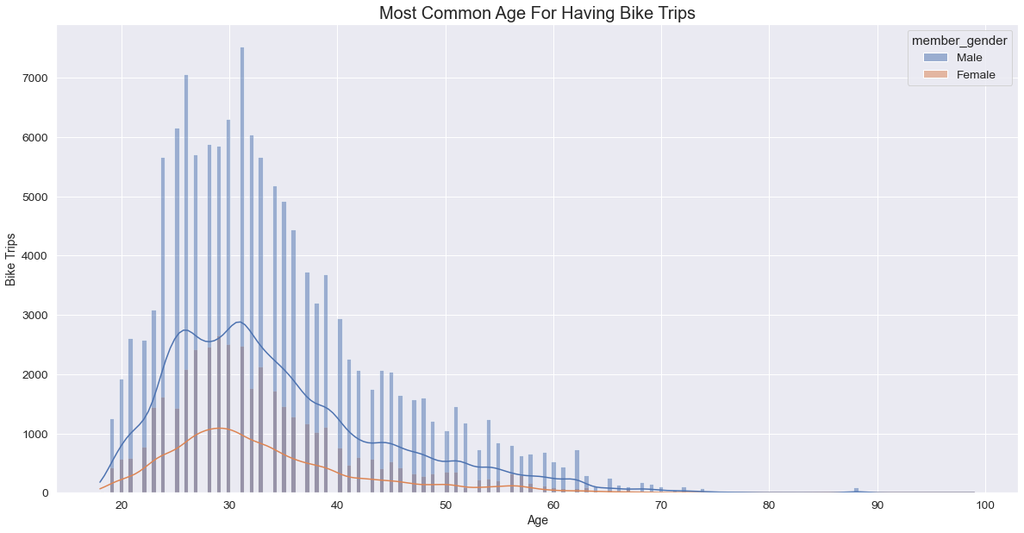

```python
fig, ax = plt.subplots(figsize=(20,10))
ax = sb.histplot(data=bike_df, x=bike_df['age'], hue='member_gender', kde=True)
plt.title('Most Common Age For Having Bike Trips', fontsize=20)
plt.ylabel('Bike Trips', fontsize=14)
plt.xlabel('Age', fontsize=14);
```

- Most of the users (subcribers & customers) are found to be between the age of 25 - 40. Shows more of youths embrace the use of this bike system.
1. **What is the relation between age & trip duration?**

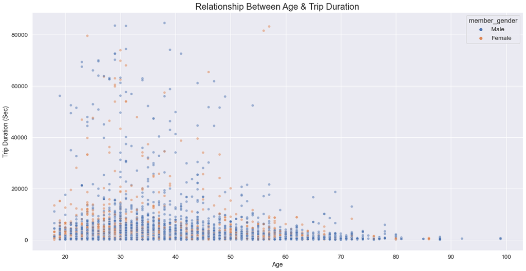

```python
fig, ax = plt.subplots(figsize=(20,10))
ax = sb.scatterplot(data=bike_df, y=bike_df['duration_sec'], x=bike_df['age'], hue='member_gender', alpha=0.5)
plt.title('Relationship Between Age & Trip Duration', fontsize=20)
plt.ylabel('Trip Duration (Sec)', fontsize=14)
plt.xlabel('Age', fontsize=14);
```

- This is just a scatter plot to show the age and gender distribution of the users of the bike system. While the most of our users age tends to like between 25 - 45 with most men highly represented across all age groups.
1. **What is the effect of the days of the week on trip durations?**

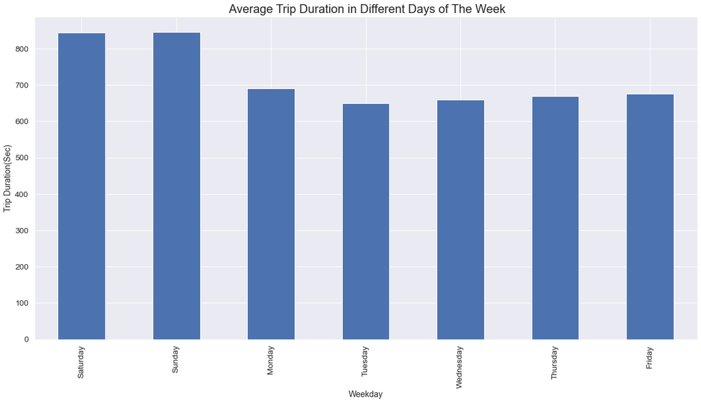

```python
fig, ax = plt.subplots(figsize=(20,10))
df_dur = bike_df.groupby('start_day_of_week')['duration_sec'].mean()[['Saturday', 'Sunday','Monday','Tuesday','Wednesday','Thursday','Friday']]
ax = df_dur.plot(kind='bar')
plt.title(' Average Trip Duration in Different Days of The Week', fontsize=20)
plt.xlabel('Weekday', fontsize=14)
plt.ylabel('Trip Duration(Sec)', fontsize=14);
```

- Average trip duration have an obvious domination on Saturdays and Sundays which is during the weekends where both subscribers and customers can have more time to ride, exercise, cylce rather than ride only to work and end.

#### To check for percentage of riders per age group, I would create a function to group the age column.

```python
def category(age):
    if 10<age<=20:
        return '11-20'

    elif 20<age<=30:
        return '21-30'

    elif 30<age<=40:
        return '31-40'

    elif 40<age<=50:
        return '41-50'

    elif 50<age<=60:
        return '51-60'

bike_df['age_category'] = bike_df['age'].apply(category)
```

```python
bike_df['age_category'].value_counts()
```

```
21-30    68869
31-40    62262
41-50    21589
51-60    10901
11-20     4204
Name: age_category, dtype: int64
```

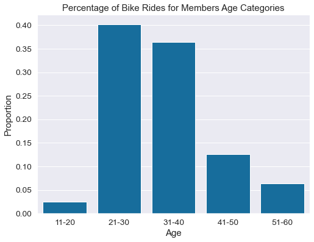

```python
n_points = bike_df.shape[0]

max_count_age = bike_df['age_category'].value_counts().max()
max_prop_age = max_count_age / n_points

tick_props_age = np.arange(0, max_prop_age, 0.05)
tick_names_age = ['{:0.2f}'.format(v) for v in tick_props_age]

my_order = ['11-20', '21-30', '31-40', '41-50', '51-60']
sb.countplot(data=bike_df, x='age_category', color=base_color, order=my_order)

ax = plt.gca()
plt.yticks(tick_props_age * n_points, tick_names_age)
ax.set_ylabel('Proportion')
ax.set_xlabel('Age')
ax.set_title("Percentage of Bike Rides for Members Age Categories", fontsize=15);
```

- The age group of the bike users greatly falls between 21 - 40, with a combined percentage of 76% of all users.

## Bivariate Exploration

```python
bike_df.info()
```

```
<class 'pandas.core.frame.DataFrame'>
Int64Index: 171234 entries, 0 to 183411
Data columns (total 14 columns):
 #   Column                   Non-Null Count   Dtype
---  ------                   --------------   -----
 0   duration_sec             171234 non-null  int64
 1   bike_id                  171234 non-null  int64
 2   user_type                171234 non-null  object
 3   member_gender            171234 non-null  object
 4   bike_share_for_all_trip  171234 non-null  object
 5   duration_minute          171234 non-null  float64
 6   start_day                171234 non-null  int64
 7   start_day_of_week        171234 non-null  category
 8   start_hour               171234 non-null  int64
 9   end_day                  171234 non-null  int64
 10  end_day_of_week          171234 non-null  object
 11  end_hour                 171234 non-null  int64
 12  age                      171234 non-null  float64
 13  age_category             167825 non-null  object
dtypes: category(1), float64(2), int64(6), object(5)
memory usage: 22.5+ MB
```

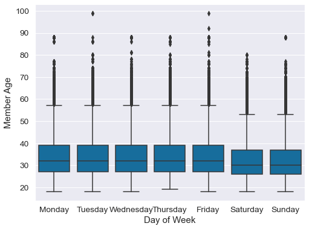

```python
# Member age by weekdays

sb.boxplot(data=bike_df, x='start_day_of_week', y='age', color=base_color);
plt.xlabel('Day of Week');
plt.ylabel('Member Age');
```

- Riders who rented the bikes Monday through Friday are slightly older than those who ride on weekends, which corresponds to the commute to work usage that was observed from the above univariable exploration plots.

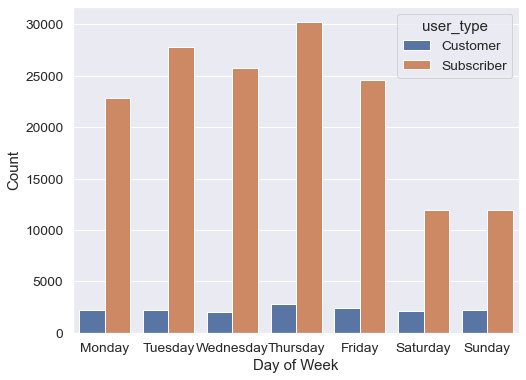

```python
# Weekly usage between customers and subscirbers

sb.countplot(data=bike_df, x='start_day_of_week', hue='user_type');
plt.xlabel('Day of Week');
plt.ylabel('Count');
```

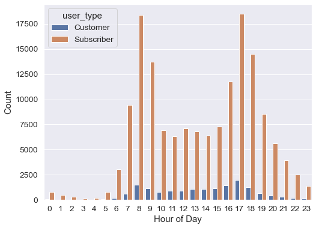

```python
# Daily usage between customers and subscribers

sb.countplot(data=bike_df, x='start_hour', hue='user_type');
plt.xlabel('Hour of Day');
plt.ylabel('Count');
```

- Subscriber usage clearly peaks out on typical rush hours when people go to work in the morning and getting off work in the afternoon, double confirmed their usage purpose and goal of riding. Similar pattern was not observed among customers who tend to ride most in the afternoon or early evening as for a different purpose than the subscriber riders.

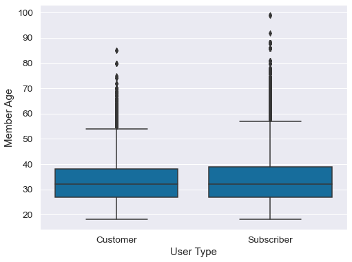

```python
# Member age between customers and subscribers

sb.boxplot(data=bike_df, x='user_type', y='age', color=base_color);
plt.xlabel('User Type');
plt.ylabel('Member Age');
```

- Similar to the Member age by weekdays plot, subscribers who ride most often Monday through Friday are slightly older than customers, with a wider range of ages as well.

## Multivariate Exploration

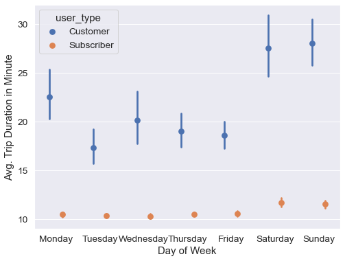

```python
# How does the average trip duration vary in weekdays between customers and subscribers?

sb.pointplot(data=bike_df, x='start_day_of_week', y='duration_minute', hue='user_type', dodge=0.3, linestyles="");
plt.xlabel('Day of Week');
plt.ylabel('Avg. Trip Duration in Minute');
```

- It can be seen from the above plot that subscribers ride much shorter/quicker trips compared to customers on each day of the week. Both user types have an obvious increase of trip duration on Saturdays and Sundays over weekends, especially for casual riders. Subscribers usage seems to be more efficient than customers overall and maintained a very consistent average duration Monday through Friday.

```python
bike_df.columns
```

```
Index(['duration_sec', 'bike_id', 'user_type', 'member_gender',
       'bike_share_for_all_trip', 'duration_minute', 'start_day',
       'start_day_of_week', 'start_hour', 'end_day', 'end_day_of_week',
       'end_hour', 'age', 'age_category'],
      dtype='object')
```

```python
bike_df.duration_minute.describe([.01,.1,.2,.3,.4,.5,.6,.7,.8,.9,.99]).apply(lambda x: format(x, 'f'))
```

```
count    171234.000000
mean         11.629593
std          26.292516
min           1.016667
1%            1.733333
10%           3.550000
20%           4.783333
30%           5.950000
40%           7.166667
50%           8.483333
60%          10.033333
70%          11.935000
80%          14.583333
90%          19.266667
99%          51.872333
max        1409.133333
Name: duration_minute, dtype: object
```

```python
temp_df = bike_df[bike_df.duration_minute < 2*bike_df.duration_minute.mean()] # 2*mean
print(bike_df.shape[0])
print(temp_df.shape[0])
```

```
171234
160652
```

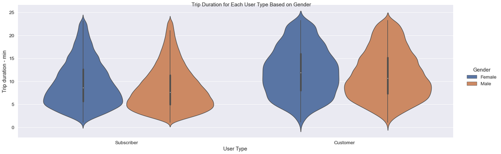

```python
ax = sb.catplot(data=temp_df, x='user_type', y="duration_minute", hue="member_gender", kind="violin", height=6, aspect=3)

ax.set_axis_labels("User Type", "Trip duration - min")
ax._legend.set_title('Gender')
ax.fig.suptitle('Trip Duration for Each User Type Based on Gender', fontsize=15);
```

- The figure above is to show the duration (in minutes) for all trips for each user type based on gender. We can see the customer users have higher duration than subscriber users.

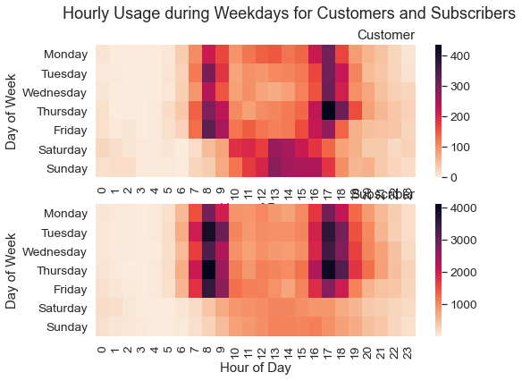

```python
# How does the hourly usage during the weekdays for customers and subscribers?

plt.suptitle('Hourly Usage during Weekdays for Customers and Subscribers')

plt.subplot(2, 1, 1)
customers = bike_df.query('user_type == "Customer"')
ct_counts = customers.groupby(['start_day_of_week', 'start_hour']).size()
ct_counts = ct_counts.reset_index(name='count')
ct_counts = ct_counts.pivot(index='start_day_of_week', columns='start_hour', values='count')
sb.heatmap(ct_counts, cmap='rocket_r');
plt.title('Customer', loc='right');
plt.xlabel('Hour of Day');
plt.ylabel('Day of Week');

plt.subplot(2, 1, 2)
subscribers = bike_df.query('user_type == "Subscriber"')
st_counts = subscribers.groupby(['start_day_of_week', 'start_hour']).size()
st_counts = st_counts.reset_index(name='count')
st_counts = st_counts.pivot(index='start_day_of_week', columns='start_hour', values='count')
sb.heatmap(st_counts, cmap='rocket_r');
plt.title('Subscriber', loc='right');
plt.xlabel('Hour of Day');
plt.ylabel('Day of Week');
```

- The heatmaps shows clearly very different usage pattern/habit between the two type of riders. Subscribers use the system heavily on work days i.e. Monday through Friday whereas customers ride a lot on weekends, especially in the afternoon. Many trips concentrated around 8-9am and 17-18pm on work days for subscribers when used for work commute, yet customers tend to use more in the late afternoon around 17pm Monday to Friday. Other than usage purpose and habit, it may also have to do with the traffic situation around these rush hours in the area.

### Talk about some of the relationships you observed in this part of the investigation. Were there features that strengthened each other in terms of looking at your feature(s) of interest?

> - The multivariate exploration strengthened some of the patterns discovered in the previous bivariate exploration as well as univariate exploration. The efficient period of usage for subscribers corresponds to their high concentration on rush hours Monday through Friday, indicating the use is primarily for work commute. The more relaxing and flexible pattern of customer use shows that they're taking advantage of the bike sharing system quite differently from the subscribers, heavily over weekends and in the afternoon, for city tour or leisure purpose probably.

### Were there any interesting or surprising interactions between features?

> - The interactions between features are all supplementing each other and quite make sense when looked at combined, there's no big surprise observed. The usage habit difference between male and female was also not surprising.

### Findings in Data Cleaning Process

1. Missing values were found and removed as they didn't show any statistical significance
2. Datetime columns types were modified to datetime type
3. New columns were created from datetime columns (showing day, day of week, hour) to give more insights. Datetime columns were removed afterwards.
4. New Column was created to show age and age group instead of birth year and birth year column was removed.
5. Outliers were checked in age columns and removed due to non-statistical significance.
6. All unnecessary columns were removed to focus more on the significant data columns.

### Findings in Data from exploratory visualizations

1. Most Users are subscribers, as most of the total trips are for subscribers showing that people will be more likely to engage in the service on consistent basis and subscribe.
2. Males represent around 76.2 % of the total trips giving more indication about females not prefering bikes as a go-to for workouts.
3. Age range is mostly between 25 & 35 years, giving high indication that youth are more interested in bike trips.
4. People use bikes mostly on working days (Monday - Friday) as they use it on regular basis not just for entrtainment.
5. Rush hour in bike trips would be between around 8 AM till 6 PM.
6. Trips duration is highest at age range from 20 to 40 as expected as they are the most users.